```r
library(here)
library(tibble)
library(ranger)
library(caret)
library(ggplot2)

source(here("v2","src","evidencegeom.R"))

set.seed(42)
```

## Dataset 3: UCI Heart Disease Cleveland

## TL;DR

This notebook demonstrates the **Evidence Geometry** framework on the **UCI Heart Disease Cleveland** dataset.

Instead of relying only on classifier probability, the framework analyzes each case by collecting log likelihood ratios between classes by selecting marginal likelihood distribution families for each feature based on feature type and magnitude of log likelihood.

This log-likelihood ratio space (evidence space) is then analyzed using two geometric risk signals:

- **Distance Contrast (`d_dist`)**: measures which class manifold better explains the case
- **Drift Projection (`proj`)**: measures directional drift toward positive-class structure

### Validation Set Risk Map

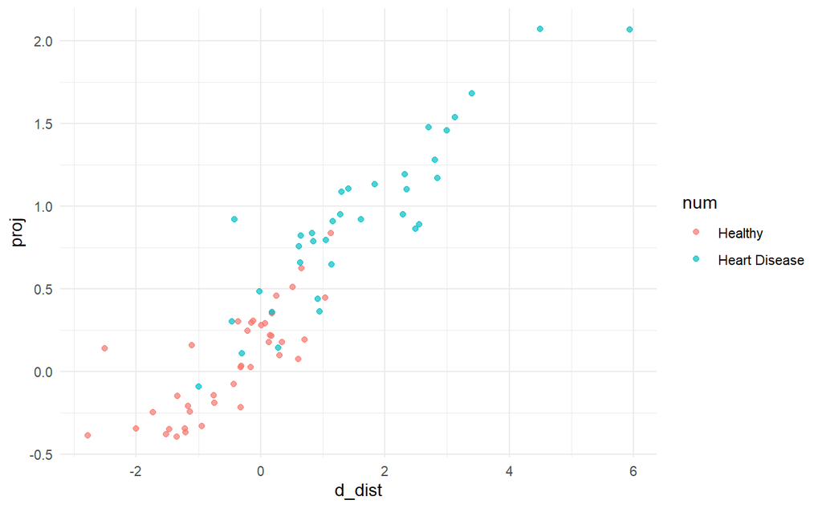

*Validation-set risk map.*

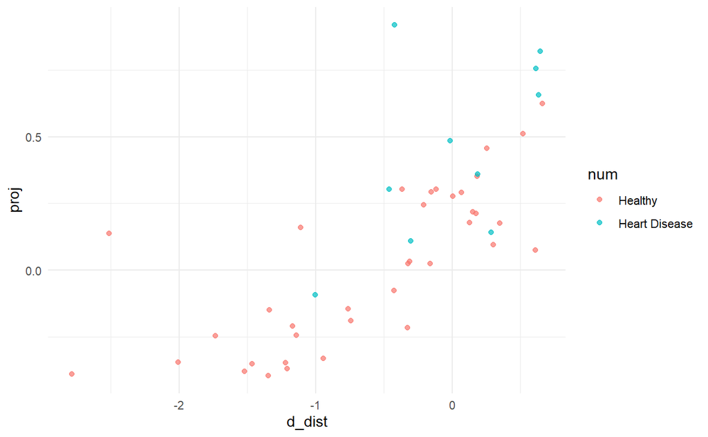

### Main Observation

Within the subset of cases assigned **low probability by the Random Forest classifier**, the two geometric signals reveal additional structure:

- Boundary of ambiguity, d_dist = 0, occurs much earlier in the feature space than p = 0.5 classifier ambiguous region.
- Dominant benign cluster is present in the region d_dist < 0, proj < 0.
- Pathological cases are distinctly present among benign points that cross the benign central region of d_dist < 0 and proj < 0.

This suggests that geometric evidence can detect **hidden risk structure earlier than classifier probability alone**.

### Takeaway

`d_dist` and `proj` provide a compact and interpretable view of **how risk accumulates geometrically**, especially in cases where standard discriminative classifiers assign deceptively low probability.

## Full Analysis

### Comment Block : Data prep of raw UCI Heart Disease Cleveland data

```r
# heartdisease <- read.csv(here("v2","src","data","heartdisease","processed.cleveland.data"))
#
# names(heartdisease) <- c("age","sex","cp","trestbps","chol","fbs","restecg","thalach","exang","oldpeak","slope","ca","thal","num")
#
# heartdisease$slope <- as.factor(
#   case_when(
#     heartdisease$slope == 1 ~ "Upsloping",
#     heartdisease$slope == 2 ~ "Flat",
#     heartdisease$slope == 3 ~ "Downsloping",
#     TRUE ~ "Unknown"
#   )
# )
#
#
# heartdisease$restecg <- as.factor(
#   case_when(
#     heartdisease$restecg == 0 ~ "Normal",
#     heartdisease$restecg == 1 ~ "ST-T Wave Abnormality",
#     heartdisease$restecg == 2 ~ "Probable Left Ventricular Hypertrophy",
#     TRUE ~ "Unknown"
#   )
# )
#
#
# heartdisease$cp <- as.factor(case_when(
#   heartdisease$cp == 1 ~ "Typical Angina",
#   heartdisease$cp == 2 ~ "Atypical Angina",
#   heartdisease$cp == 3 ~ "Non-anginal Pain",
#   heartdisease$cp == 4 ~ "Asymptomatic",
#   TRUE ~ "Unknown"
# ))
#
#
# heartdisease$thal <- as.factor(
#   case_when(
#     heartdisease$thal == "3.0" ~ "Normal",
#     heartdisease$thal == "6.0" ~ "Fixed Defect",
#     heartdisease$thal == "7.0" ~ "Reversible Defect",
#     TRUE ~ "Unknown"
#   )
# )
#
#
# heartdisease$ca <- as.integer(heartdisease$ca)
#
#
# heartdisease$fbs <- ifelse(heartdisease$fbs == 1, TRUE, FALSE)
# heartdisease$exang <- ifelse(heartdisease$exang == 1, TRUE, FALSE)
#
#
# heartdisease$sex <- as.factor(ifelse(heartdisease$sex == 1, "M", "F"))
#
#
# heartdisease <- drop_na(heartdisease)
#
#
# heartdisease$num <- as.factor(
#   case_when(
#     heartdisease$num < 1 ~ "Healthy",
#     heartdisease$num >= 1 ~ "Heart Disease",
#     TRUE ~ "Unknown"
#   )
# )
```

```r
# heartdisease_train_idx <- caret::createDataPartition(heartdisease$num, p=0.5, list=FALSE)
# heartdisease_train <- heartdisease[heartdisease_train_idx, ]
# heartdisease_eval <- heartdisease[-heartdisease_train_idx, ]
#
# heartdisease_val_idx <- createDataPartition(heartdisease_eval$num, p=0.5, list=FALSE)
# heartdisease_val <- heartdisease_eval[heartdisease_val_idx, ]
# heartdisease_test <- heartdisease_eval[-heartdisease_val_idx, ]
```

```r
# write.csv(heartdisease_train, here("v2","src","data","heartdisease","heartdisease_train.csv"))
# write.csv(heartdisease_val, here("v2","src","data","heartdisease","heartdisease_val.csv"))
# write.csv(heartdisease_test, here("v2","src","data","heartdisease","heartdisease_test.csv"))
```

### Load Test-Val-Train Splits

```r
heartdisease_train <- read.csv(here("v2", "src", "data", "heartdisease", "heartdisease_train.csv"))
heartdisease_val <- read.csv(here("v2", "src", "data", "heartdisease", "heartdisease_val.csv"))
heartdisease_test <- read.csv(here("v2", "src", "data", "heartdisease", "heartdisease_test.csv"))
```

```r
heartdisease_train[sapply(heartdisease_train, is.character)] <- lapply(heartdisease_train[sapply(heartdisease_train, is.character)], as.factor)
heartdisease_train$ca <- as.factor(heartdisease_train$ca)

heartdisease_val[sapply(heartdisease_val, is.character)] <- lapply(heartdisease_val[sapply(heartdisease_val, is.character)], as.factor)
heartdisease_val$ca <- as.factor(heartdisease_val$ca)

heartdisease_test[sapply(heartdisease_test, is.character)] <- lapply(heartdisease_test[sapply(heartdisease_test, is.character)], as.factor)
heartdisease_test$ca <- as.factor(heartdisease_test$ca)
```

### Class Ratio to input for generating Evidence Space

```r
alpha <- (nrow(heartdisease_train[heartdisease_train$num=="Heart Disease", ])/nrow(heartdisease_train))
```

## Evidence Space Transformation

**risk_spec** : Object to store function argument values for evidence space generation

**fit** : Learn feature-wise marginal likelihoods, and geometries and eigenmodes of class manifolds in evidence space

**loglik_matrices** : Compute marginal positive-class and negative-class evidences, and marginal relative evidence for input data using fitted evidence generator

**score_risk** : Compute total feature-wise evidence, distance constrast, drift projection, and eigenmode energies

### Generate Evidence Space

```r
spec <- risk_spec(
   y_col="num", positive="Heart Disease",
   features = setdiff(names(heartdisease_train), c("num", "X")),
   alpha = alpha,
   laplace = 1, ridge = 1e-6, winsor_p=0.01,
   weights=FALSE,
   weight_method = "mutual_info",
   numeric_candidates = c("gaussian", "lognormal", "gamma"),
   numeric_val_frac = 0.2,
   numeric_min_n = 25,
   llr_cap_quantile = 0.01,
   mi_nbins = 10
 )

obj <- fit(heartdisease_train%>%select(-X), spec, k_eigen=2, k_energy=2, energy_ref="both")
```

```r
print_feature_likelihoods(obj)
```

```
##     feature    class feature_type likelihood_family
## 1       age positive      numeric          gaussian
## 2       age negative      numeric          gaussian
## 3  trestbps positive      numeric         lognormal
## 4  trestbps negative      numeric         lognormal
## 5      chol positive      numeric         lognormal
## 6      chol negative      numeric         lognormal
## 7   thalach positive      numeric          gaussian
## 8   thalach negative      numeric          gaussian
## 9   oldpeak positive      numeric          gaussian
## 10  oldpeak negative      numeric          gaussian
## 11      sex positive  categorical       categorical
## 12      sex negative  categorical       categorical
## 13       cp positive  categorical       categorical
## 14       cp negative  categorical       categorical
```

[output cut: 39 more lines]

```r
Lval <- loglik_matrices(heartdisease_val%>%select(-X), obj$fit, alpha=spec$alpha)
# val/test scoring
scores_val <- bind_cols(id=heartdisease_val$X,
                            num=heartdisease_val$num,
                            score_risk(Lval$l_pos, Lval$l_neg,  obj$fit$weights, obj$geom,
                                       spec$alpha, spec$eps))
```

### Learn baseline Random Forest and predict

```r
rf_train_1 <- ranger(formula = num ~ ., data=heartdisease_train%>%select(-X),
                         mtry=4, min.node.size=5, num.trees=500, probability = TRUE,
                         keep.inbag = TRUE)
```

```r
scores_val <- bind_cols(scores_val,
                            p = predict(rf_train_1, heartdisease_val%>%select(-X, -num))$predictions[,"Heart Disease"])
```

### Sample from evidence output

**l_pos** : Sum of marginal positive evidence  
**l_neg** : Sum of marginal negative evidence  
**l** : Sum of marginal evidence (difference of positive and negative evidence)  
**proj** : Projection of benign-relative z scores of evidences on mean deviation class separation direction learned from training  
**d_dist** : Difference of Mahalanobis Distances of evidence vector from negative-class evidence manifold and positive-class evidence manifold  
**E_pos** : Total energy (sum of squares of projections over k principal components of positive-class) of evidence vector  
**p** : Random Forest probability score for positive-class

```r
head(scores_val, 5)
```

```
##   id           num     l_pos     l_neg          l         t        proj
## 1  3       Healthy -32.72783 -31.81197 -0.9158537 -64.53980  0.19364106
## 2  8 Heart Disease -21.27192 -25.94749  4.6755715 -47.21941  0.95111451
## 3 13       Healthy -28.04745 -22.89964 -5.1478114 -50.94709 -0.07533242
## 4 14       Healthy -29.23021 -25.74143 -3.4887798 -54.97164  0.03387516
## 5 19       Healthy -27.38981 -20.55902 -6.8307984 -47.94883 -0.32935053
##       d_dist   l_norm      E_pos      E_neg         dE      eig_1      eig_2
## 1  0.7112194 6.459184 36.6215886 40.5967927 -3.9752041 -4.0419595  4.6754727
## 2  1.2833701 2.358627  1.3733554  8.0427772 -6.6694217 -0.7951663 -1.3908320
## 3 -0.4273574 2.912674  1.0661917  0.2625656  0.8036261  1.2476962  0.5504127
## 4 -0.3117642 2.752718  0.5386055  0.7794078 -0.2408023  1.0482897  0.3405261
## 5 -0.9436319 2.682278  0.9711189  1.1449501 -0.1738312  1.7888525  1.7904853
##           p
## 1 0.3388667
## 2 0.9379000
## 3 0.2757000
## 4 0.2797000
## 5 0.0198000
```

### Feature Importance using ratio of feature-wise evidences

```r
feature_importance(df=heartdisease_train, y_col="num", fit = obj$fit, method = "mutual_info", top_n = 15)
```

```
##     feature     weight abs_weight
## 1      thal 0.18129883 0.18129883
## 2        cp 0.15105583 0.15105583
## 3   thalach 0.12796960 0.12796960
## 4   oldpeak 0.12442872 0.12442872
## 5     slope 0.12368637 0.12368637
## 6        ca 0.12210565 0.12210565
## 7       age 0.08550260 0.08550260
## 8  trestbps 0.04523472 0.04523472
## 9      chol 0.02436100 0.02436100
## 10  restecg 0.01435668 0.01435668
## 11      sex 0.00000000 0.00000000
## 12      fbs 0.00000000 0.00000000
## 13    exang 0.00000000 0.00000000
```

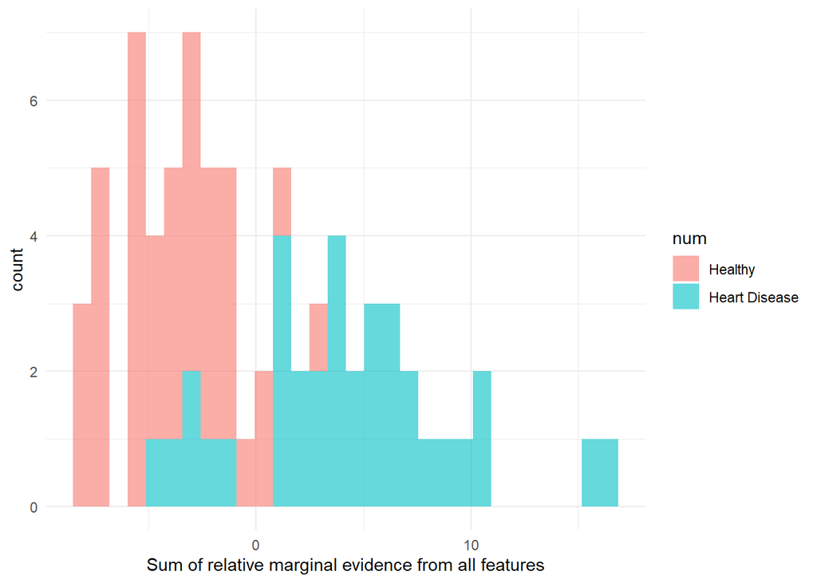

```r
ggplot(scores_val) +
  geom_histogram(aes(x=l, fill=num), alpha=0.6) +
  xlab("Sum of relative marginal evidence from all features") +
  theme_minimal()
```

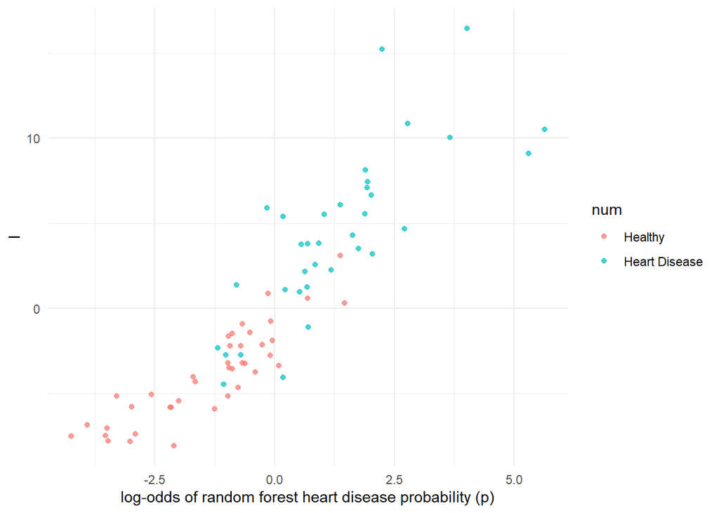

```r
ggplot(scores_val) +
  geom_point(aes(x=qlogis(p), y=l, color=num), alpha=0.7) +
  xlab("log-odds of random forest heart disease probability (p)") +
  theme_minimal()
```

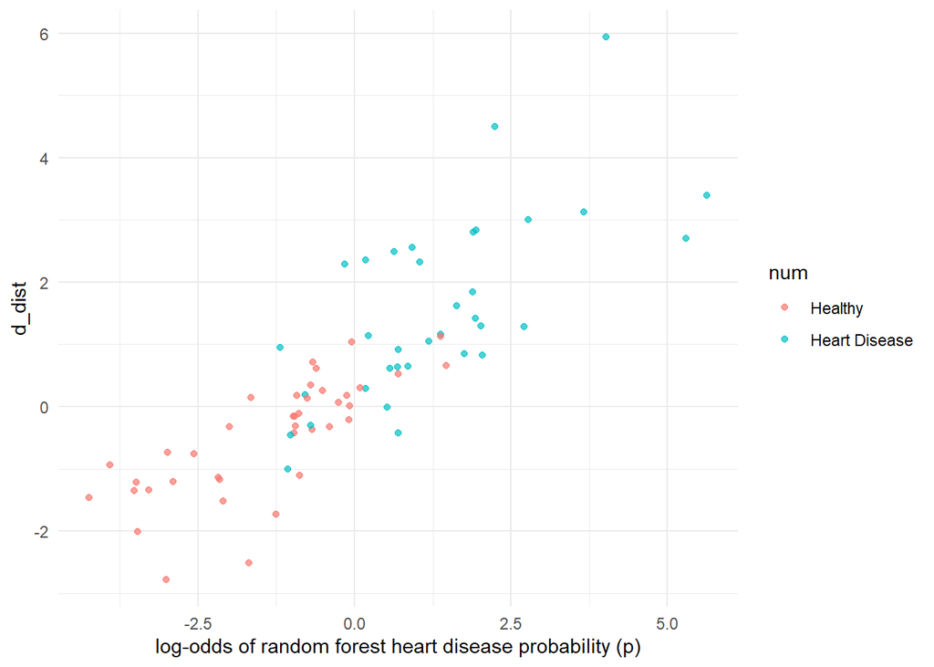

```r
ggplot(scores_val) +
  geom_point(aes(x=qlogis(p), y=d_dist, color=num), alpha=0.7) +
  xlab("log-odds of random forest heart disease probability (p)") +
  theme_minimal()
```

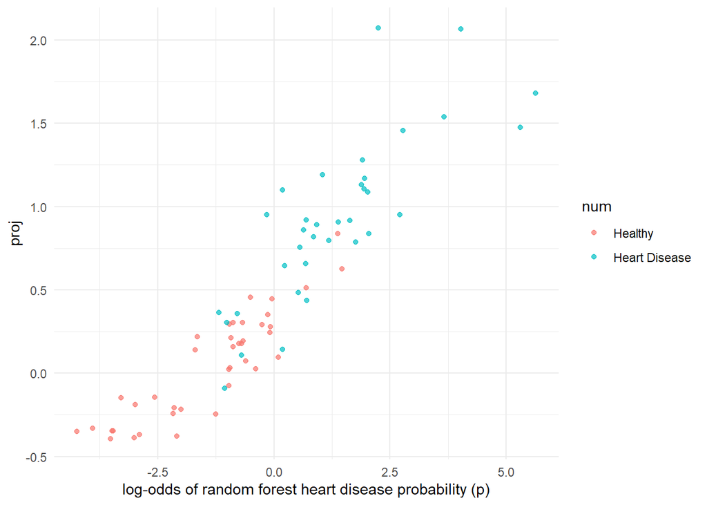

```r
ggplot(scores_val) +
  geom_point(aes(x=qlogis(p), y=proj, color=num), alpha=0.7) +
  xlab("log-odds of random forest heart disease probability (p)") +
  theme_minimal()
```

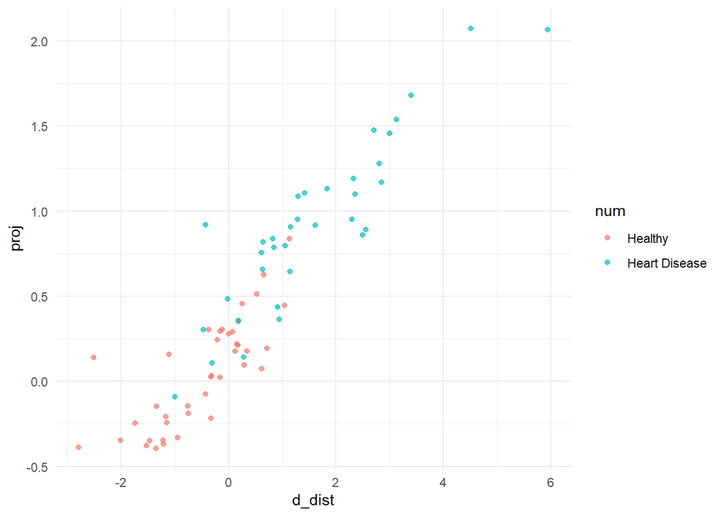

```r
ggplot(scores_val) +
  geom_point(aes(x=d_dist, y=proj, color=num), alpha=0.7) +
  theme_minimal()
```

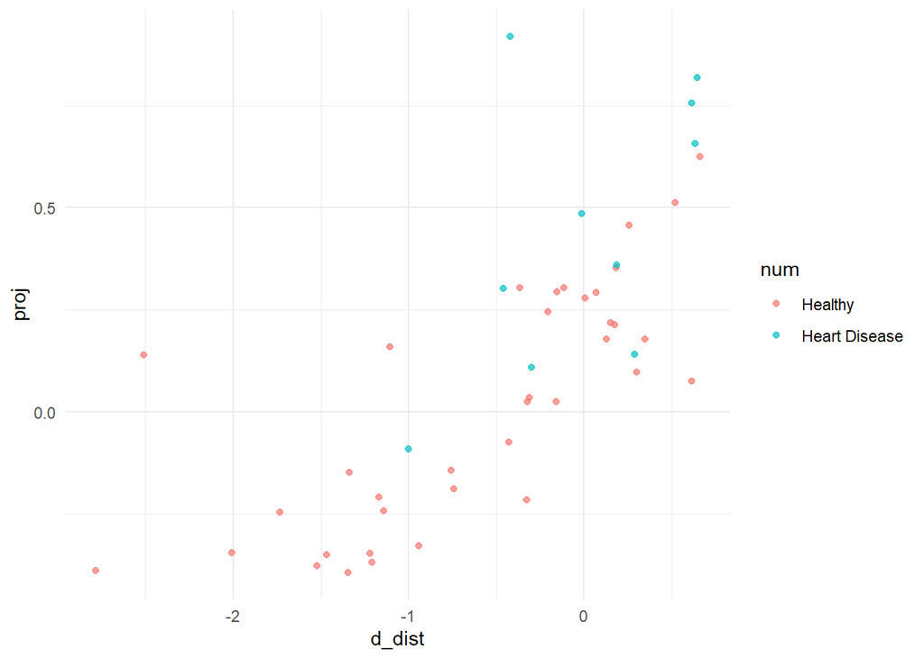

```r
ggplot(scores_val%>%filter(d_dist < 0.7)) +
  geom_point(aes(x=d_dist, y=proj, color=num), alpha=0.7) +
  theme_minimal()
```

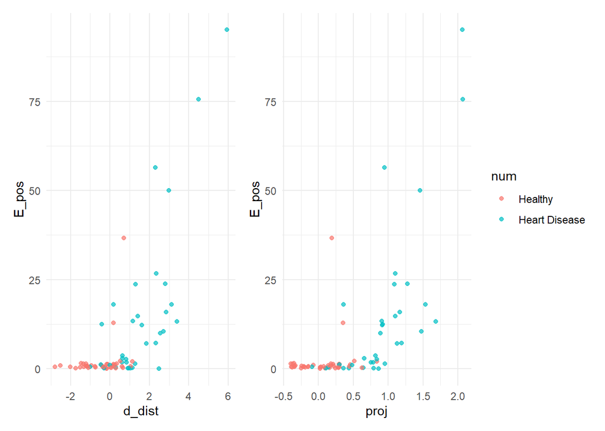

```r
patchwork::wrap_plots(

ggplot(scores_val) +
  geom_point(aes(x=d_dist, y=E_pos, color=num), alpha=0.7) +
  theme_minimal(),

ggplot(scores_val) +
  geom_point(aes(x=proj, y=E_pos, color=num), alpha=0.7) +
  theme_minimal()
) + patchwork::plot_layout(guides="collect")
```

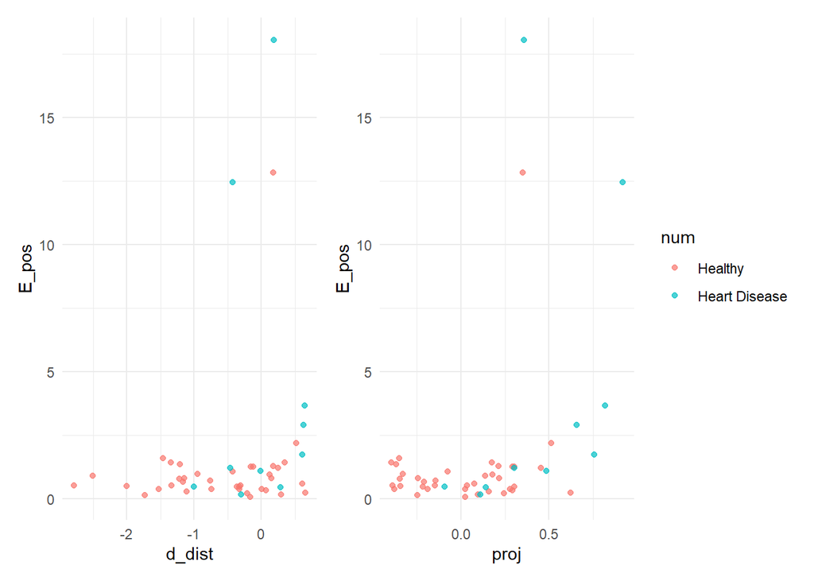

```r
patchwork::wrap_plots(

ggplot(scores_val%>%filter(d_dist < 0.7, E_pos < 400)) +
  geom_point(aes(x=d_dist, y=E_pos, color=num), alpha=0.7) +
  theme_minimal(),

ggplot(scores_val%>%filter(d_dist < 0.7, E_pos < 400)) +
  geom_point(aes(x=proj, y=E_pos, color=num), alpha=0.7) +
  theme_minimal()
) + patchwork::plot_layout(guides="collect")
```

```r
Lval_w <- apply_llr_weights(Lval$L, obj$fit$weights)
```

### Eigenmode Decomposition (PCA) of Heart Disease subset

```r
Lval_w_M <- Lval_w[heartdisease_val$num == "Heart Disease", , drop = FALSE]
Lval_w_Sigma_M <- cov(Lval_w_M)
Lval_w_Sigma_M <- Lval_w_Sigma_M + diag(1e-6, ncol(Lval_w_Sigma_M))
Lval_w_eig_M <- eigen(Lval_w_Sigma_M, symmetric = TRUE)

Lval_w_eigvals_M  <- Lval_w_eig_M$values
Lval_w_eigvecs_M  <- Lval_w_eig_M$vectors

Lval_w_coords_M <- Lval_w_M %*% Lval_w_eigvecs_M[, 1:2]
```

#### Variance Explained

```r
Lval_w_eigvals_M[1:2] / sum(Lval_w_eigvals_M[1:2])
```

```
## [1] 0.7778224 0.2221776
```

#### Top 5 feature loadings

```r
decompose_eigenmode(Lval_w_eigvecs_M, k=1, feature_names = obj$fit$features, top_n=5)
```

```
## # A tibble: 5 × 3
##   feature  loading abs_loading
##   <chr>      <dbl>       <dbl>
## 1 oldpeak   0.977       0.977
## 2 slope     0.129       0.129
## 3 exang     0.108       0.108
## 4 thal      0.0935      0.0935
## 5 trestbps  0.0511      0.0511
```

```r
decompose_eigenmode(Lval_w_eigvecs_M, k=2, feature_names = obj$fit$features, top_n=5)
```

```
## # A tibble: 5 × 3
##   feature loading abs_loading
##   <chr>     <dbl>       <dbl>
## 1 ca        0.565       0.565
## 2 thal     -0.565       0.565
## 3 thalach   0.512       0.512
## 4 age       0.249       0.249
## 5 exang    -0.130       0.130
```

#### Eigenmode Decomposition (PCA) of Healthy subset

```r
Lval_w_B <- Lval_w[heartdisease_val$num == "Healthy", , drop = FALSE]
Lval_w_Sigma_B <- cov(Lval_w_B)
Lval_w_Sigma_B <- Lval_w_Sigma_B + diag(1e-6, ncol(Lval_w_Sigma_B))
Lval_w_eig_B <- eigen(Lval_w_Sigma_B, symmetric = TRUE)

Lval_w_eigvals_B  <- Lval_w_eig_B$values
Lval_w_eigvecs_B  <- Lval_w_eig_B$vectors

Lval_w_coords_B <- Lval_w_B %*% Lval_w_eigvecs_B[, 1:2]
```

#### Variance Explained

```r
Lval_w_eigvals_B[1:2] / sum(Lval_w_eigvals_B[1:2])
```

```
## [1] 0.5197891 0.4802109
```

Top 5 feature loadings

```r
decompose_eigenmode(Lval_w_eigvecs_B, k=1, feature_names = obj$fit$features, top_n=5)
```

```
## # A tibble: 5 × 3
##   feature loading abs_loading
##   <chr>     <dbl>       <dbl>
## 1 ca        0.738       0.738
## 2 oldpeak  -0.452       0.452
## 3 age       0.340       0.340
## 4 slope    -0.290       0.290
## 5 sex      -0.174       0.174
```

```r
decompose_eigenmode(Lval_w_eigvecs_B, k=2, feature_names = obj$fit$features, top_n=5)
```

```
## # A tibble: 5 × 3
##   feature loading abs_loading
##   <chr>     <dbl>       <dbl>
## 1 thal     -0.604       0.604
## 2 oldpeak   0.592       0.592
## 3 ca        0.303       0.303
## 4 sex      -0.292       0.292
## 5 slope     0.247       0.247
```

```r
acos((t(Lval_w_eigvecs_B[,1]) %*% Lval_w_eigvecs_M[,1]) / (sqrt(t(Lval_w_eigvecs_B[,1]) %*% Lval_w_eigvecs_B[,1]) * sqrt(t(Lval_w_eigvecs_M[,1]) %*% Lval_w_eigvecs_M[,1]))) * 180 / pi
```

```
##          [,1]
## [1,] 118.2988
```

## Fitting Evidence Model and Random Forest on train+val set

```r
obj_2 <- fit(bind_rows(heartdisease_train%>%select(-X),
                           heartdisease_val%>%select(-X)), spec, k_eigen=2, k_energy=2, energy_ref="both")
```

```r
Ltest <- loglik_matrices(heartdisease_test%>%select(-X), obj_2$fit, alpha=spec$alpha)
# val/test scoring
scores_test <- bind_cols(X=heartdisease_test$X,
                            num=heartdisease_test$num,

                            score_risk(Ltest$l_pos, Ltest$l_neg,  obj_2$fit$weights, obj_2$geom,
                                       spec$alpha, spec$eps))
```

```r
feature_importance(df=bind_rows(heartdisease_train%>%select(-X),
                           heartdisease_val%>%select(-X)), y_col="num", fit = obj_2$fit, method = "mutual_info", top_n = 15)
```

```
##     feature     weight abs_weight
## 1      thal 0.16758747 0.16758747
## 2   thalach 0.16458909 0.16458909
## 3        cp 0.16227125 0.16227125
## 4   oldpeak 0.15959587 0.15959587
## 5     slope 0.11678890 0.11678890
## 6        ca 0.08996638 0.08996638
## 7       age 0.08094144 0.08094144
## 8  trestbps 0.03139123 0.03139123
## 9      chol 0.02686837 0.02686837
## 10      sex 0.00000000 0.00000000
## 11      fbs 0.00000000 0.00000000
## 12  restecg 0.00000000 0.00000000
## 13    exang 0.00000000 0.00000000
```

```r
print_feature_likelihoods(obj_2)
```

```
##     feature    class feature_type likelihood_family
## 1       age positive      numeric          gaussian
## 2       age negative      numeric          gaussian
## 3  trestbps positive      numeric         lognormal
## 4  trestbps negative      numeric         lognormal
## 5      chol positive      numeric         lognormal
## 6      chol negative      numeric         lognormal
## 7   thalach positive      numeric          gaussian
## 8   thalach negative      numeric          gaussian
## 9   oldpeak positive      numeric          gaussian
## 10  oldpeak negative      numeric          gaussian
## 11      sex positive  categorical       categorical
## 12      sex negative  categorical       categorical
## 13       cp positive  categorical       categorical
## 14       cp negative  categorical       categorical
```

[output cut: 39 more lines]

```r
rf_train_2 <- ranger(formula = num ~ ., data=bind_rows(heartdisease_train%>%select(-X), heartdisease_val%>%select(-X)),
                         mtry=4, min.node.size=5, num.trees=500, probability = TRUE,
                         keep.inbag = TRUE)
```

## Test Set Performance

```r
scores_test <- bind_cols(scores_test,
                            p = predict(rf_train_2, heartdisease_test%>%select(-X))$predictions[,"Heart Disease"])
```

### Triage Rule

**If** $p \geq 0.65$ $\rightarrow$ **Heart Disease**  
**Else If** $p > 0.45$ $\rightarrow$ **Review**  
**Else**  
**If** $proj > 0$ $\rightarrow$ **Review**  
**Else If** $d\_dist \geq 0$ $\rightarrow$ **Review**  
**Else** $\rightarrow$ **Healthy**

```r
apply_triage <- function(df, p_hi = 0.65, p_review = 0.45, tau_d = 0, tau_p = 0) {
  df %>%
    mutate(
      action = case_when(
        p >= p_hi ~ "Disease",
        p > p_review ~ "Review",
        (p <= p_review) & (proj > tau_p) ~ "Review",
        (p <= p_review) & (d_dist >= tau_d) ~ "Review",
        TRUE ~ "Healthy"
      )
    )
}

triage_table <- function(df, truth_col, action_col = "action") {
  tab <- table(df[[action_col]], df[[truth_col]])
  as.data.frame.matrix(tab) %>%
    tibble::rownames_to_column(action_col)
}
```

### Triage Results

```r
test_triaged <- scores_test %>%
  apply_triage(p_hi = 0.65, p_review = 0.45, tau_d = 0, tau_p = 0)

triage_table(test_triaged, truth_col = "num", action_col = "action")
```

```
##    action Healthy Heart Disease
## 1 Disease       2            20
## 2 Healthy      22             1
## 3  Review      16            13
```

```r
test_metrics <- function(df, truth_col, levels, p_col) {
  truth <- df[[truth_col]]
  stopifnot(all(levels(truth) %in% levels))

  benign_path <- df %>% filter(action == "Healthy")
  review_path <- df %>% filter(action == "Review")
  mal_path <- df %>% filter(action == "Disease")

  tibble(
    auto_benign_fn_rate = mean(benign_path[[truth_col]] == levels[2]),
    fn_capture_rate = 1 - mean(df[[truth_col]] == levels[2] & df$action == "Healthy"),
    overall_review_rate = mean(df$action == "Review"),
    benign_region_review_rate = mean(df[[p_col]] <= 0.45 & df$action == "Review") / mean(df[[p_col]] <= 0.45),
    malignant_region_fp_override_rate = mean(df[[p_col]] >= 0.65 & df[[truth_col]] == levels[1]) / mean(df[[p_col]] >= 0.65) # optional
  )
}

test_metrics(test_triaged, truth_col="num", p_col="p", levels=levels(heartdisease_test$num))
```

```
## # A tibble: 1 × 5
##   auto_benign_fn_rate fn_capture_rate overall_review_rate benign_region_review…¹
##                 <dbl>           <dbl>               <dbl>                  <dbl>
## 1              0.0435           0.986               0.392                  0.378
## # ℹ abbreviated name: ¹benign_region_review_rate
## # ℹ 1 more variable: malignant_region_fp_override_rate <dbl>
```